# Upwork–Projet Tuteuré

# Introduction

Notre mémoire porte sur l’étude exploratoire d’une plate‐forme en ligne de travailleurs indépendants « free‐lancers ». Nous avons choisi Upwork, une plate‐forme numérique dont l’objectif est d’apparier des travailleurs indépendants « free‐lance » (e.g. consultants, développeurs en Informatique) à des entreprises recherchant des compétences très ciblées. La plate‐forme permet à des entreprises de « poster » leurs offres puis à des travailleurs indépendants de contacter ces entreprises et de démarrer éventuellement une collaboration. La plate‐forme propose différents services permettant de faciliter cette mise en contact. En particulier, elle propose un service d’évaluation des travailleurs indépendants. Notre objectif est de faire une analyse exploratoire des questions suivantes :

*1. Décrire les profils‐type des entreprises et des travailleurs indépendants s’adressant à la plate‐forme*

*2. Identifier les déterminants de la notation effectuée par la plate‐forme*

*3. Identifier les déterminants du prix de la prestation ainsi que du mode de rémunération (paiement fixe ou variable)*

Dans ce travail, nous allons d’abord collecter les données en faisant du web scraping, ensuite effectuer un prétraitement et une analyse descriptive des données. Par la suite, nous ferons une analyse économétrique en faisant une modélisation et nous discuterons sur les résultats.

# I Hypothèses

*H1: Le score de réussite (job success) peut avoir une influence positive sur le top rated.*

En effet, le Score de réussite professionnelle Upwork est une mesure de la qualité du travail et de la réputation sur Upwork. Le score est basé sur la façon dont les clients classent la performance d’un pigiste sur une période de 24 mois. Les clients aiment savoir qu’ils embauchent des pigistes qui ont une bonne réputation pour leur travail et leur prestation de qualité. Une bonne notation par les clients entraine une augmentation du score de réussite. Cela permettra au pigiste de décrocher davantage de jobs et d’avoir un job sucess au-delà de 90% d’être noté Top rated.

*H2: Le prix peut avoir une influence négative sur le top rated*

Le taux horaire que peut fixer un freelancer peut impacter son job success. Par exemple lorsqu’un freelancer fixe un prix élevé, il aura du mal à avoir de clients et de décrocher moins de jobs, ce qui peut entrainer que le pigiste ou le freelancer faisant parti d’une agence ou non ne sera pas noté top rated.

# II Données

## 2. Description des varriables

Nos variables sont interprétés comme suit :

```
1. Nom: C’est les noms de famille et les prénoms des Freelancer qui sont sur le site qu’on étudie.

2. Pays: C’est la nationalité de chaque individu, nous savons que la situation de développement des
        pays différents sont vraiment différents, ce genre de différence peut donner les influences
        sur le niveau de salaire ou le temps de travail ou le niveau de strict de projets, etc. Donc
        dans notre recherche, nous pouvons faire l’analyse dans les 2 grandes groupes (les pays déve-
        loppés, les pays en développement) si nous avons besoins.

3. Total_jobs: C’est le nombre de jobs décroché par un freelancer.

4. Total_heure: Ce sont les heures de travail totale d’un freelancer, ça nous affiche directement le
                niveau d’expérience d’individus.

5. Prix: c’est le tarif horaire par projet ou forfaitaire. Ce tarif peut varier selon l’expérience et
         les compétences du freelanceur. Un tarif élevé signifie que le freelanceur est expérimenté ou
         a beaucoup de compétences.

6. Job_succes: Le Job Success Score (JSS) agit comme un système métrique pour évaluer la performance
               d’un pigiste (ou d’une agence) en termes de qualité de travail, de capacité à maintenir
               des relations à long terme avec les clients et, en plus de cela, les compétences nécess-
               aires pour récolter d’excellents commentaires privés. Les heures de travail sont mesurées
               par l’application Team. Les clients ont la prérogative de définir certaines exigences et
               cela peut inclure à la fois le JSS et le nombre d’heures de travail d’un pigiste ou d’une                       agence.

7. Top_rated: Variable binaire (noté 0: le freelancer n’est pas noté top rated et 1: sino). Elle met en
              évidence les professionnels qui se sont bâti une solide réputation sur Upwork en obtenant
              des commentaires positifs de leurs clients, à chaque fois. Ils représentent les 10% de ta-
              lents les plus performants sur Upwork.

8. Rating: variable binaire (0 : le freelancer n’a pas reçu d’avis du tout et 1: si oui).

9. Agence: variable binaire (0 : si le freelancer n’a pas d’agence et 1: si oui).
```

## 3. Les origines des freelancers

|  | Les pays | Nombre des freelancers |
| --- | --- | --- |
| 1 | Albania | 1 |
| 2 | Argentina | 13 |
| 3 | Armenia | 5 |
| 4 | Australia | 3 |
| 5 | Bangladesh | 12 |
| 6 | Belarus | 5 |
| 7 | Benin | 1 |
| 8 | BosniaandHerzegovina | 1 |
| 9 | Brazil | 13 |
| 10 | Bulgaria | 2 |
| 11 | Cameroon | 2 |
| 12 | Canada | 8 |
| 13 | Chile | 1 |
| 14 | China | 7 |
| 15 | Colombia | 6 |
| 16 | Coted’Ivoire | 1 |
| 17 | Croatia | 2 |
| 18 | Cyprus | 2 |
| 19 | CzechRepublic | 1 |
| 20 | DominicanRepublic | 1 |
| 21 | Ecuador | 2 |
| 22 | Egypt | 10 |
| 23 | ElSalvador | 1 |
| 24 | Estonia | 2 |
| 25 | France | 3 |
| 26 | Georgia | 3 |
| 27 | Germany | 1 |
| 28 | Greece | 3 |
| 29 | Haiti | 1 |
| 30 | Honduras | 2 |
| 31 | India | 47 |
| 32 | Indonesia | 3 |
| 33 | Italy | 1 |
| 34 | Jordan | 1 |
| 35 | Kenya | 1 |
| 36 | Lithuania | 1 |
| 37 | Macedonia | 4 |
| 38 | Mexico | 3 |
| 39 | Moldova | 1 |
| 40 | Morocco | 2 |
| 41 | Myanmar | 1 |
| 42 | Netherlands | 1 |
| 43 | Pakistan | 29 |
| 44 | PalestinianTerritories | 1 |
| 45 | Peru | 2 |
| 46 | Philippines | 18 |
| 47 | Poland | 3 |
| 48 | Portugal | 1 |
| 49 | Romania | 2 |
| 50 | Russia | 25 |
| 51 | Senegal | 1 |
| 52 | Serbia | 4 |
| 53 | Singapore | 4 |
| 54 | SouthKorea | 4 |
| 55 | Spain | 6 |
| 56 | SriLanka | 1 |
| 57 | Switzerland | 1 |
| 58 | Tanzania | 1 |
| 59 | Thailand | 3 |
| 60 | Ukraine | 130 |
| 61 | UnitedKingdom | 10 |
| 62 | UnitedStates | 83 |
| 63 | Venezuela | 8 |
| 64 | Vietnam | 2 |

Les 520 freelancers de notre base viennent 64 pays différents dans le monde. En regardant la distribution de nombres de freelancers de chaque pays, la distribution est très bipolaire, donc nous mettons 10 comme le seuil pour savoir les origines principales des freelancers de notre base.

|  | Les pays | Nombre des freelancers |
| --- | --- | --- |
| 2 | Argentina | 13 |
| 5 | Bangladesh | 12 |
| 9 | Brazil | 13 |
| 22 | Egypt | 10 |
| 31 | India | 47 |
| 43 | Pakistan | 29 |
| 46 | Philippines | 18 |
| 50 | Russia | 25 |
| 60 | Ukraine | 130 |
| 61 | UnitedKingdom | 10 |
| 62 | UnitedStates | 83 |

Dans la base, il y a 11 pays qui sont au-delà de notre seuil, ils sont : l’Argentina, le Bangladesh, le Brazil, l’Égypte, l’Inde, le Pakistan, la Philippines, la Russie, l’Ukraine, le Royaume-Uni et les États-Unis. Les 3 principales origines sont l’Ukraine, les États-Unis et l’Inde (En ordre décroissant). Nous trouvons que le résultat est intéressant, le nombre des freelancers d’Ukraine est plus beaucoup que celui des États-Unis, et l’inde devient le 3ème plus grand offreur de travailleurs dans le site.

Nous pensons que le site est très connu aux États-Unis, et les langues de travails sont plutôt comme l’anglais, c’est car ça nous avons plusieurs de freelancers qui viennent des pays d’anglophones (comme les États-Unis et le Royaume-Uni) ou les pays qui utilise souvent l’anglais comme la 2ème langue officielle (comme l’Inde, la Philippines, etc).

### La distribution des valeurs manquantes dans la base initiale

|  | na_count |
| --- | --- |
| Nom | 0 |
| Pays | 0 |
| Total_jobs | 0 |
| Total_heure | 28 |
| Prix | 0 |
| job_successe | 51 |
| Top_Rated | 2 |
| Rating | 2 |
| Agence | 0 |

Nous trouvons que la plupart de valeur manquantes vient de la variables Total_heure et job_successe. En réfléchissant le but de notre recherche est pour obtenir une règle générale pour mesurer les influences des variables explicatives à notre variable expliquée. Donc nous avons utilisés le valeur moyenne des 2 variables à remplacer les valeurs manquantes. Et aussi pour les 2 variables explicative ‘Top_Rated’ et ‘Rating’, les 2 valeurs manquantes vient des 2 personnes pareil, donc nous les avons supprimés parce que une fois que nous changeons directement quelques valeurs de la variable expliquée, nous aurons plus de possibilité à avoir un résultat biaisé, mais sur les variables explicatives si on supprime 2 observations, il n’aura pas beaucoup d’influences sur la modélisation même le résultat que nous voulons savoir par les données.

## 4. Traitement

**Les techniques à traiter les valeurs manquantes:**

**La création néccessaire de variables “salaire_total”:**

```
##    Min. 1st Qu.  Median    Mean 3rd Qu.    Max.
##       0    3092   17060  135017   83114 4473485
```

Afin de mesurer grossièrement l’effet du salaire sur la variable expliquée, nous avons créé une nouvelle variable explicative, le salaire total (= salaire horaire * heures de travail). Étant donné que le salaire horaire d’un pigiste sur ce site augmente avec l’expérience de travail est une donnée de panel, la valeur de cette variable est une mesure approximative et non une représentation fidèle du pigiste du revenu total des activités de recherche d’emploi sur ce site.

Et nous trouvons que cette variable est aussi très bipolaire, mais la médiane peut bien décrire la situation de salaire total. La médiane de salaire totale parmi les freelancers est de 17060 dollars. Mais le freelancer qui a le plus de richesse a gagné 4473485 dollars, il y a aussi des personnes n’a pas eu encore le salaire, peut-être qu’il vient d’inscrire son compte ou qu’il a changé le platform à trouver le travail. Et pour les étapes prochaines, nous utiliserons 2 bases différentes pour mesurer l’influences des valeurs aberrantes de notre table (distingué par l’existence de valeurs hyper grandes ou petites), et 2 autres bases différentes pour mesurer si pour les variables explicatives qu’on a choisies ont des différentes influences sur les 2 genres de freelancers (travaillent dans les agences ou non.)

## 5. Visualisation des données

### Les variables quantitatives

Nous avons fait la visualisation à partir de la base initiale, c’est-à-dire que la base qui contient les valeurs aberrantes.

Il y a 2 grande partie dans la visualisation, nous allons interpréter les variables quantitatives et les variables qualitatives séparément.

Les variables quantitatives :

### Les variables quantitatives

**Total_jobs:**

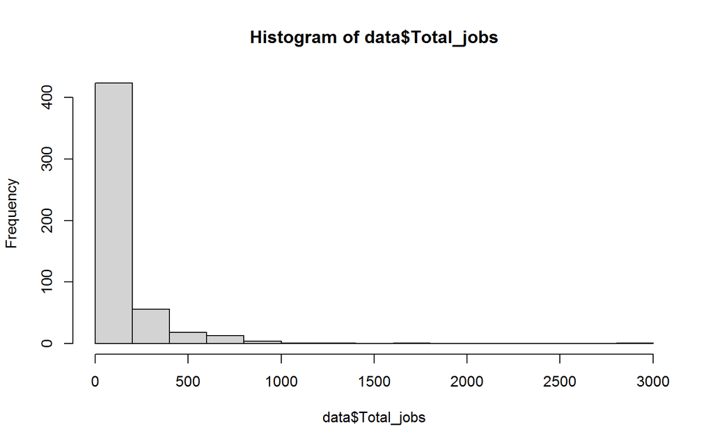

Par l’histogramme, nous trouvons que les freelancers qui a obtenue moins de 500 jobs sont s’occupent la plupart des observations dans notre base, et parmi eux, les gens qui a fait 0-200 travails s’occupent la plupart de personne. Il y a plusieurs de méthode qui nous permet d’expliquer ce genre de situation, mais nous pensons que la raison c’est la plupart de personne sont les nouveaux utilisateurs de ce site.

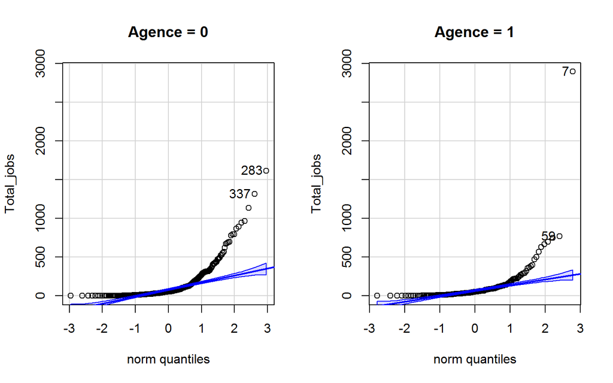

**Total_heure:**

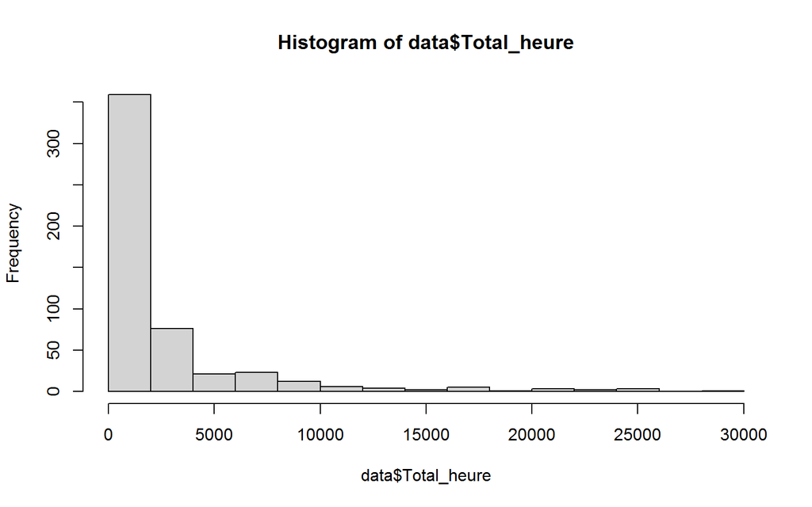

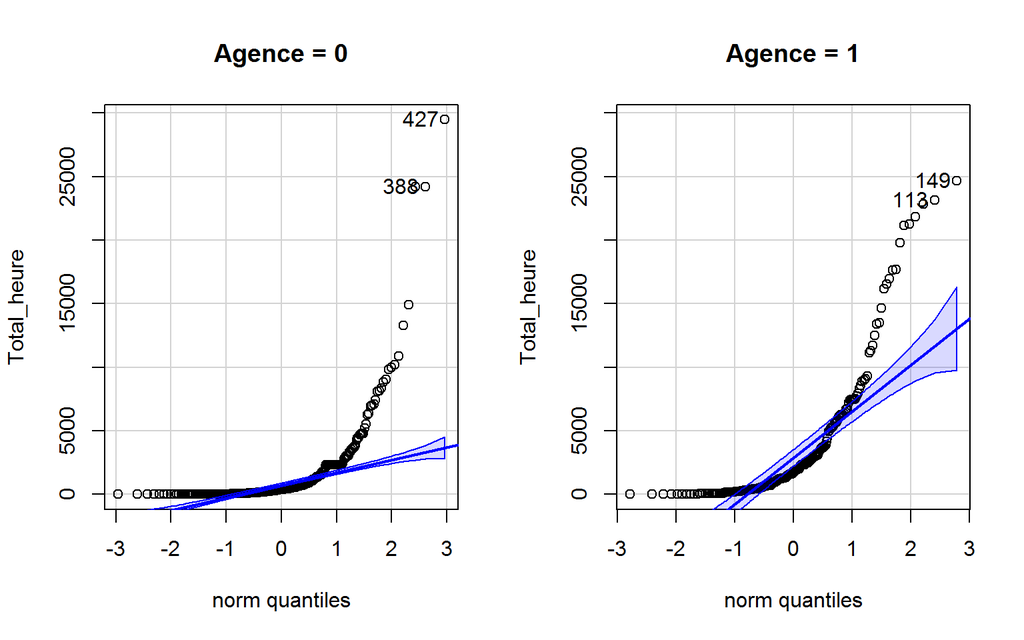

Sur la distribution normale, nous trouvons que les freelancers qui travaillent dans les agences suivent mieux que l’autre genre de freelancer. Et au point de vue des valeurs numérique des points dispersés, nous trouvons que celui des freelancers qui non pas d’agences ont des valeurs plus grandes (par exemple le point 427, et les points qui proches de 20000h). Nous croyons que les freelancers qui n’ont pas des agences n’ont pas beaucoup d’opportunité de travaillent c’est peut expliquer qu’ils ont moins de totale d’heure de travails que l’autre genre de freelancer, et sur l’observarion 427, nous jugeons que peut-être qu’il s’abandonne quelques-uns de ses projets ou c’est vrai qu’il a des projets prend trop de temps ayant le prix haut.

**Prix:**

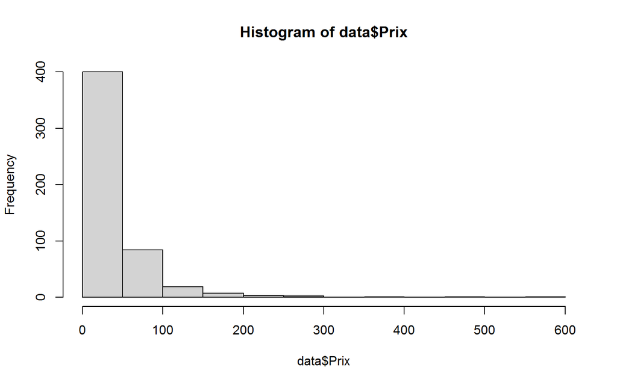

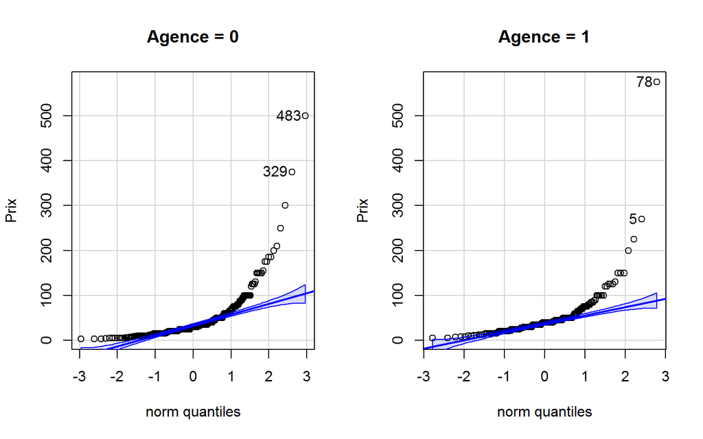

La situation de la distribution normale des freelancers quin ont des l’agences est mieux que l’autre genre. Et le freelancer qui ont le prix maximum vient de ce groupe aussi. Et il y a un phénomène intéressant c’est qu’il y a plus de personnes qui ont de salaire plus de 150 dollars parmi les freelancers qui n’ont pas d’agences. Et nous ne savons pas que si c’est à cause des travails d’agences qui donne des limites aux freelancers à gagner plus…

**job_successe:**

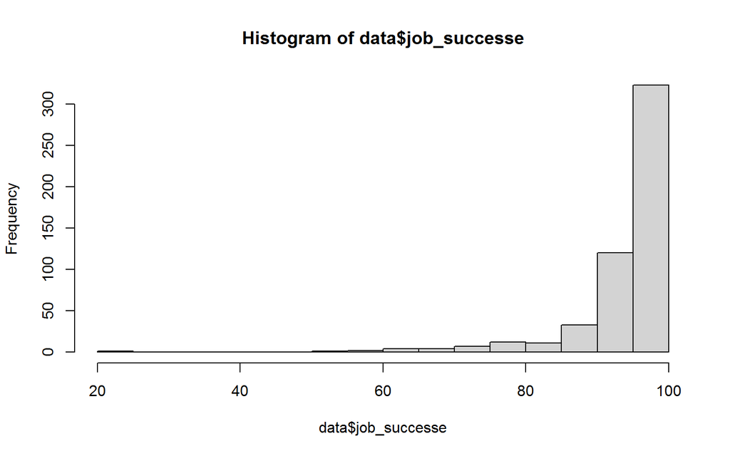

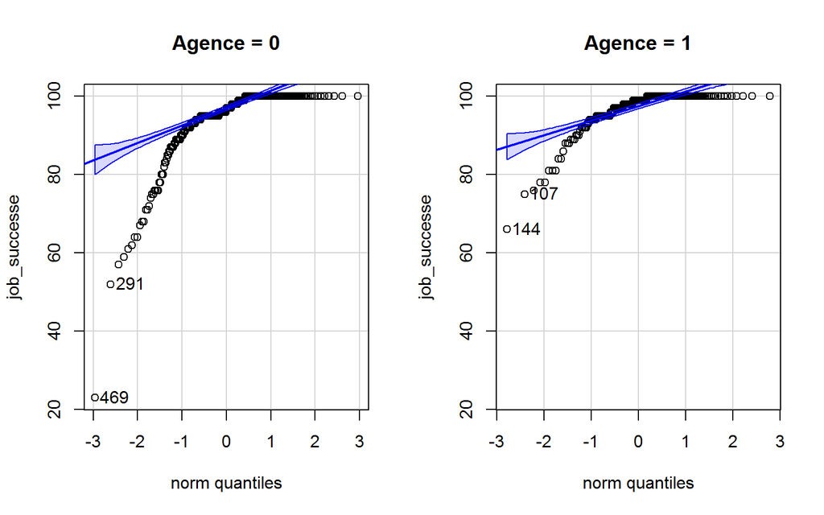

Nous trouvons qu’il y a plus des freelancers qui ont le taux de réussite moin de 80% dans le groupe des freelancer non agences, et que le freelancer qui ont le minimum taux de réussite est aussi dans ce groupe, mais par contre, dans l’autre groupe, la distribution de valeurs est plus stable. Nous pouvons conclure qu’au niveau de taux de réussite, les freelancer qui travaillent dans les agences sont plus fort.

**Analyser généralement**

**Top_Rated:**

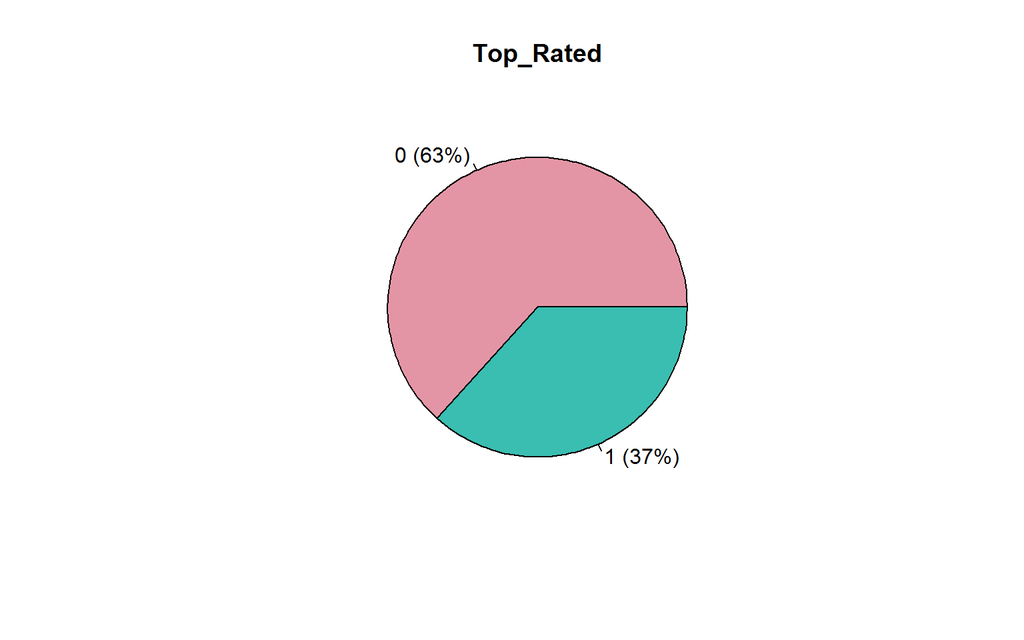

Elle est notre variable expliquée, et nous trouvons que parmi les observations, il y a plus d’une moitié de freelancers n’est pas vérifié par le site en donnant le ticket « Top Rated » sur ses pages personnelles. Il y a juste 37% de freelancers sont déjè vérifié. Il y a une méthode stricte à donner cette identification aux freelancers par le site.

**Rating:**

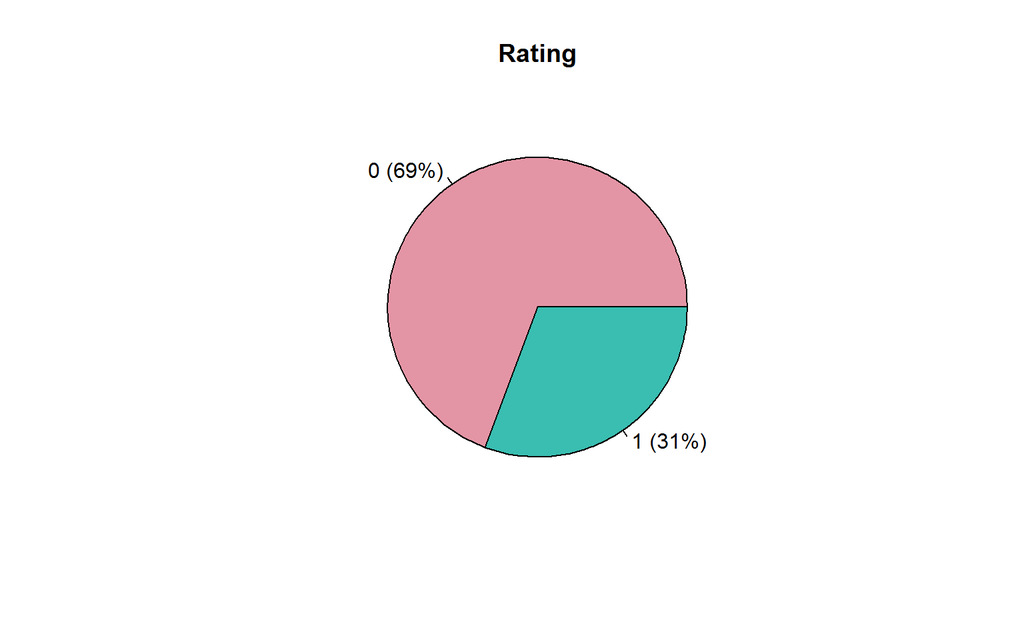

**Agence:**

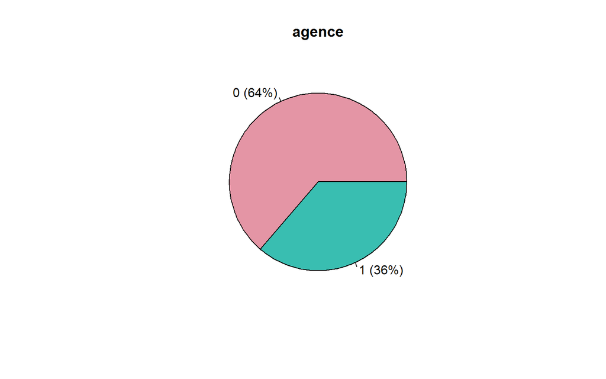

Dans notre base, les freelancers qui n’ont pas de agences s’occupent 64%, et les freelancers qui travaillent pour les agences s’occupent 36%, le premier groupe ont presque 2 fois de nombre que le deuxième groupe.

# III Analyse économique

Nous voulons faire :

```
            1. Les analyses économique à partir de 2 base(celle avec la valeur aberrante et non aberrante)


            2. En éliminant les valeurs aberrantes, les influences des variables qu'on a eu sur la varaible
               expliquée.
```

## 1. Statistique descriptives(de la base nette)

### Corrélation et les tests

**La matrice de correlation entre les variables quantitatives**

|  | Total_jobs | Prix | job_successe | Total_heure |
| --- | --- | --- | --- | --- |
| Total_jobs | 1.00 | 0.11 | 0.04 | 0.22 |
| Prix | 0.11 | 1.00 | 0.13 | 0.07 |
| job_successe | 0.04 | 0.13 | 1.00 | 0.11 |
| Total_heure | 0.22 | 0.07 | 0.11 | 1.00 |

**Test des corrélation**

1. Entre Prix et job_successe

Pearson’s product-moment correlation: `job_successe` and `Prix`

| Test statistic | df | P value | Alternative hypothesis | cor |
| --- | --- | --- | --- | --- |
| 3.034 | 516 | 0.002532 * * | two.sided | 0.1324 |

2. Entre Prix et Total_heure

Pearson’s product-moment correlation: `Total_heure` and `Prix`

[output not shown]

3. Entre Total_job et Total_heure

Pearson’s product-moment correlation: `Total_heure` and `Prix`

[output not shown]

## 2.Modèle principal

1.Modèle

|  | Estimate | Std. Error | z value | Pr(>\|z\|) |
| --- | --- | --- | --- | --- |
| (Intercept) | 29.0346 | 3.3070 | 8.78 | 0.0000 |
| Total_heure | -0.0001 | 0.0000 | -1.10 | 0.2699 |
| Total_jobs | -0.0050 | 0.0012 | -4.28 | 0.0000 |
| Prix | -0.0037 | 0.0030 | -1.22 | 0.2210 |
| job_successe | -0.2994 | 0.0340 | -8.81 | 0.0000 |
| Rating1 | 0.1401 | 0.2500 | 0.56 | 0.5752 |
| Agence1 | -0.3938 | 0.2576 | -1.53 | 0.1264 |

2.VIF(Vérifiation d’autocorelation)

|  | x |
| --- | --- |
| Total_heure | 1.116828 |
| Total_jobs | 1.099376 |
| Prix | 1.010745 |
| job_successe | 1.047506 |
| Rating | 1.010899 |
| Agence | 1.099257 |

3. odds ratios:

|  | x |
| --- | --- |
| (Intercept) | 4.069776e+12 |
| Total_heure | 9.999473e-01 |
| Total_jobs | 9.950514e-01 |
| Prix | 9.962864e-01 |
| job_successe | 7.412666e-01 |
| Rating1 | 1.150370e+00 |
| Agence1 | 6.744762e-01 |

**Interpretation du modèle principal**

Cependant, nous pouvons tester la robustesse de notre modele principal par plusieurs méthodes. D’une part en tenant en compte les valeurs aberrantes dans notre modèle principal et d’autre part en séparer la base de données en 2 (Freelancer avec agence et sans agence) et les analyser séparément.

### Test de robustesse Modèle principale

|  | Estimate | Std. Error | z value | Pr(>\|z\|) |
| --- | --- | --- | --- | --- |
| (Intercept) | 29.1114 | 3.3124 | 8.79 | 0.0000 |
| Total_heure | -0.0001 | 0.0000 | -1.73 | 0.0844 |
| Total_jobs | -0.0049 | 0.0012 | -4.24 | 0.0000 |
| Prix | -0.0039 | 0.0030 | -1.28 | 0.1993 |
| job_successe | -0.3000 | 0.0341 | -8.81 | 0.0000 |
| Rating1 | 0.1452 | 0.2500 | 0.58 | 0.5613 |
| Agence1 | -0.3743 | 0.2558 | -1.46 | 0.1435 |

*Interpretation_test_de_robustesse*

Le resultat du test montre une légére variation des variables independantes. Le but du test est d’avoir l’impact des valeurs aberrantes sur notre modèle. Nous observons qu’ici notre modèle n’est pas biaisé.

## 3. Modelisation avec les données propres(freelancers avec agences)

### Modèle agence initiale:

1. MODELE

[output not shown]

2. VIF

|  | x |
| --- | --- |
| Total_heure | 1.313227 |
| Total_jobs | 1.047733 |
| catego_jobsuc | 1.044402 |
| catego_salaire | 1.326344 |
| Prix | 1.052371 |
| Rating | 1.014491 |

3. Odds-Ratios

|  | x |
| --- | --- |
| (Intercept) | 9.7447615 |
| Total_heure | 0.9999492 |
| Total_jobs | 1.0005539 |
| catego_jobsuc1 | 0.0828996 |
| catego_salaire1 | 0.6581456 |
| Prix | 0.9952449 |
| Rating1 | 1.0012421 |

*Interprétation du Modèle des freelancers avec agence*

Nous avons supprimé la variable « Rating », dans le modèle 2 et nous trouvons qu’il n’y a pas de changement entre les coefficients des variables explicatives. En comparant modèle 2 et 3, nous trouvons que le coefficient de la variable « catego_salaire » est diminué, donc nous pouvons conclure ici on élimine l’impact des influences des prix de salaire, l’augmentation d’état de niveau de salaire peut aussi ajouter la possibilité d’avoir « Top Rated ». En comparant avec le modèle 4, nous trouvons que dans le modèle 5, la variable « catego_salaire » devient significative avec la suppression de la variable « Prix » et « Rating ».

### Test robustesse

**Robustesse avec agences**

|  | *Dependent variable:* |  |  |  |  |
| --- | --- | --- | --- | --- | --- |
|  | Top_Rated |  |  |  |  |
|  | (1) | (2) | (3) | (4) | (5) |
| Total_heure | -0.0001 | -0.0001 | -0.00005 | -0.00005 | -0.0001 |
|  | (0.00004) | (0.00004) | (0.00004) | (0.00004) | (0.00004) |
| Total_jobs | 0.001 | 0.001 |  |  | 0.001 |
|  | (0.001) | (0.001) |  |  | (0.001) |
| catego_jobsuc1 | -2.490*** | -2.490*** | -2.494*** | -2.477*** | -2.505*** |
|  | (0.509) | (0.508) | (0.505) | (0.506) | (0.507) |
| catego_salaire1 | -0.418 | -0.418 | -0.464 | -0.407 | -0.473* |
|  | (0.289) | (0.289) | (0.283) | (0.288) | (0.284) |
| Prix | -0.005 | -0.005 |  | -0.005 |  |
|  | (0.004) | (0.004) |  | (0.004) |  |
| Rating1 | 0.001 |  | -0.021 |  |  |
|  | (0.234) |  | (0.232) |  |  |
| Constant | 2.277*** | 2.277*** | 2.159*** | 2.310*** | 2.118*** |
|  | (0.575) | (0.566) | (0.550) | (0.563) | (0.543) |
| Observations | 180 | 180 | 180 | 180 | 180 |
| Log Likelihood | -79.898 | -79.898 | -81.295 | -80.172 | -80.928 |
| Akaike Inf. Crit. | 173.796 | 171.796 | 172.590 | 170.345 | 171.856 |
| *Note:* | p<0.1; p<0.05; p<0.01 |  |  |  |  |

**Robustesse avec agences**

[output not shown]

**Les odds-ratio avec agences modèle initiale**

| (Intercept) | Total_heure | Total_jobs | catego_jobsuc1 | catego_salaire1 | Prix | Rating1 |
| --- | --- | --- | --- | --- | --- | --- |
| 9.745 | 1.000 | 1.001 | 0.083 | 0.658 | 0.995 | 1.001 |

**Les odds-ratio avec agences modèle initiale**

[output not shown]

**Les odds-ratio avec agences modèle 2**

| (Intercept) | Total_heure | Total_jobs | catego_jobsuc1 | catego_salaire1 | Prix |
| --- | --- | --- | --- | --- | --- |
| 9.752 | 1.000 | 1.001 | 0.083 | 0.658 | 0.995 |

**Les odds-ratio avec agences modèle 2**

[output not shown]

**Les odds-ratio avec agences modèle 3**

| (Intercept) | Total_heure | catego_jobsuc1 | catego_salaire1 | Rating1 |
| --- | --- | --- | --- | --- |
| 8.660 | 1.000 | 0.083 | 0.629 | 0.980 |

**Les odds-ratio avec agences modèle 3**

[output not shown]

**Les odds-ratio avec agences modèle 4**

| (Intercept) | Total_heure | catego_jobsuc1 | catego_salaire1 | Prix |
| --- | --- | --- | --- | --- |
| 10.071 | 1.000 | 0.084 | 0.666 | 0.995 |

**Les odds-ratio avec agences modèle 4**

[output not shown]

**Les odds-ratio avec agences modèle 5**

| (Intercept) | Total_heure | Total_jobs | catego_jobsuc1 | catego_salaire1 |
| --- | --- | --- | --- | --- |
| 8.313 | 1.000 | 1.001 | 0.082 | 0.623 |

**Les odds-ratio avec agences modèle 5**

[output not shown]

## 4. Modelisation avec les données propres(freelancers sans agences)

### Modèle initiale:

1.MODELE

|  | Estimate | Std. Error | z value | Pr(>\|z\|) |
| --- | --- | --- | --- | --- |
| (Intercept) | 7.4032 | 188.8423 | 0.04 | 0.9687 |
| Total_heure | 0.0001 | 0.0000 | 2.46 | 0.0139 |
| Total_jobs | -0.0043 | 0.0011 | -3.95 | 0.0001 |
| catego_jobsuc1 | -7.0240 | 188.8422 | -0.04 | 0.9703 |
| catego_salaire1 | -0.8650 | 0.2230 | -3.88 | 0.0001 |
| Prix | 0.0002 | 0.0017 | 0.13 | 0.9001 |
| Rating1 | 0.2522 | 0.1917 | 1.32 | 0.1884 |

2. Odds-Ratios

[output not shown]

**Interprétation du modèle avec les Freelancers sans agence**

#### Test robustesse

**Robustesse sans agences**

|  | *Dependent variable:* |  |  |  |  |
| --- | --- | --- | --- | --- | --- |
|  | Top_Rated |  |  |  |  |
|  | (1) | (2) | (3) | (4) | (5) |
| Total_heure | 0.0001** | 0.0001 | 0.0001** | 0.0001*** | 0.0001 |
|  | (0.00004) | (0.00004) | (0.00004) | (0.00004) | (0.00004) |
| Total_jobs | -0.004*** | -0.003*** | -0.004*** | -0.004*** | -0.003*** |
|  | (0.001) | (0.001) | (0.001) | (0.001) | (0.001) |
| catego_jobsuc1 | -7.024 |  | -7.012 | -7.043 |  |
|  | (188.842) |  | (189.309) | (188.535) |  |
| catego_salaire1 | -0.865*** | -0.559*** | -0.863*** | -0.856*** | -0.553*** |
|  | (0.223) | (0.204) | (0.222) | (0.222) | (0.204) |
| Prix | 0.0002 | -0.002 |  | 0.0001 | -0.002 |
|  | (0.002) | (0.002) |  | (0.002) | (0.002) |
| Rating1 | 0.252 | 0.170 | 0.251 |  |  |
|  | (0.192) | (0.167) | (0.192) |  |  |
| Constant | 7.403 | 0.554*** | 7.398 | 7.487 | 0.595*** |
|  | (188.842) | (0.189) | (189.309) | (188.535) | (0.185) |
| Observations | 322 | 322 | 322 | 322 | 322 |
| Log Likelihood | -136.465 | -190.611 | -136.473 | -137.312 | -191.120 |
| Akaike Inf. Crit. | 286.930 | 393.221 | 284.946 | 286.623 | 392.241 |
| *Note:* | p<0.1; p<0.05; p<0.01 |  |  |  |  |

**Robustesse avec agences**

[output not shown]

**Les odds-ratio sans agences de modele initial**

| (Intercept) | Total_heure | Total_jobs | catego_jobsuc1 | catego_salaire1 | Prix | Rating1 |
| --- | --- | --- | --- | --- | --- | --- |
| 1,641.160 | 1.000 | 0.996 | 0.001 | 0.421 | 1.000 | 1.287 |

**Les odds-ratio avec agences modèle initiale**

[output not shown]

**Les odds-ratio sans agences de modele 2**

| (Intercept) | Total_heure | Total_jobs | catego_salaire1 | Prix | Rating1 |
| --- | --- | --- | --- | --- | --- |
| 1.740 | 1.000 | 0.997 | 0.572 | 0.998 | 1.185 |

**Les odds-ratio avec agences modèle 2**

[output not shown]

**Les odds-ratio sans agences de modele 3**

| (Intercept) | Total_heure | Total_jobs | catego_jobsuc1 | catego_salaire1 | Rating1 |
| --- | --- | --- | --- | --- | --- |
| 1,632.791 | 1.000 | 0.996 | 0.001 | 0.422 | 1.286 |

**Les odds-ratio avec agences modèle 3**

[output not shown]

**Les odds-ratio sans agences de modele 4**

| (Intercept) | Total_heure | Total_jobs | catego_jobsuc1 | catego_salaire1 | Prix |
| --- | --- | --- | --- | --- | --- |
| 1,785.561 | 1.000 | 0.996 | 0.001 | 0.425 | 1.000 |

**Les odds-ratio avec agences modèle 4**

[output not shown]

**Les odds-ratio sans agences de modele 5**

| (Intercept) | Total_heure | Total_jobs | catego_salaire1 | Prix |
| --- | --- | --- | --- | --- |
| 1.813 | 1.000 | 0.997 | 0.575 | 0.998 |

**Les odds-ratio avec agences modèle 5**

[output not shown]

# IV Discussion

Pour les Freelancer qui ne travaillent pas dans les agences, il y a plus des variables explicatives qui nous permet de mesurer son influence sur le résultat de la variable que nous avons choisie, mais nous trouvons que le niveau de prix ne donne pas plus d’impact que l’autre genre de Freelancer sur notre variable expliqué (contre H2b), même si l’influence est positive (Contre H2a).

Ces Résultats obtenus avec ces modèles que nous avons construits ne valident pas nos hypothèses. Cela peut être expliquer par plusieurs raisons :

**-Collectes de données insuffisantes**

**Notre base ne contient pas suffisamment d’observations, ce qui peut réduire la qualité de notre modèle :**

**-Problème d’endogénéité**

# Conclusion

Upwork est l’un des plus gros sites de freelance du marché, mais ça ne veut pas dire que c’est le meilleur. D’ailleurs, ces dernières années, la qualité du travail a baissé et il y a de plus de plus de problèmes dans la manière dont fonctionne la plateforme. Si nous prenons l’exemple du calcul de top rated, d’après nos résultats, le taux de réussite a un impact différent selon que le Freelancer appartient à une agence ou non. Parfois, malgré un job sucess élevé (>90%), le top rated du freelancer ne change pas alors que ça dépasse le nombre de semaines nécessaire pour qu’il soit évalué. Beaucoup d’utilisateurs de la plateforme rencontrent ce problème actuellement. Les métriques sont bonnes pour certaines choses mais elles ont des limites quand il s’agit de la réussite humaine. Upwork avec sa taille offre certains avantages, comme les filtres de recherche avancés, une appli mobile pratique, un dispositif de suivi du temps de travail et un système de messagerie efficace, mais il faut être prudent car des clients racontent qu’ils sont tombés sur des profils de freelancers clairement bidons.

# Références bibliographiques

*https://www.upwork.com/* *http://www.bsi-economics.org/364-%E2%98%86-%E2%98%86-quelles-sont-les-sources-d%E2%80%99endogeneite-en-econometrie#:~:text=L’endog%C3%A9n%C3%A9it%C3%A9%20est%20un%20des%20principaux%20probl%C3%A8mes%20de%20tout,(x)%20et%20le%20terme%20d’erreur%20(e)%20sera%20viol%C3%A9e.*

*https://community.upwork.com/t5/Freelancers/Job-Success-Top-Rated-Broken/m-p/263411*